# teste

```r
library(tidyr)
library(dplyr)
library(ggplot2)
library(readr)
library(tidyverse, warn.conflicts = F)
library(rvest)
library(plotly)
library(cluster)
library(ggdendro)
theme_set(theme_light())
source("plota_solucoes_hclust.R")
```

Esta análise, realizada no contexto da disciplina Análise de Dados 1 (Computação @ UFCG), tem por objetivo identificar agrupamentos sob características de Bilheteria e Avaliação dos filmes nos quais a atriz Cate Blanchett atuou. Iremos utilizar para trabalharmos com algumas técnicas de **agrupamento**.

Iremos coletar daods sobre a atriz do site Rotten Tomatoes.

```r
from_page <- read_html("https://www.rottentomatoes.com/celebrity/cate_blanchett") %>%
    html_node("#filmographyTbl") %>% # A sintaxe da expressão é de um seletor à lá JQuery: https://rdrr.io/cran/rvest/man/html_nodes.html
    html_table(fill=TRUE) %>% # Faz parse
    as.tibble()

filmes = from_page %>%
    filter(RATING != "No Score Yet",
           `BOX OFFICE` != "—",
           CREDIT != "Executive Producer") %>%
    mutate(RATING = as.numeric(gsub("%", "", RATING)),
           `BOX OFFICE` = as.numeric(gsub("[$|M]", "", `BOX OFFICE`))) %>%
    filter(`BOX OFFICE` >= 1) # Tem dois filmes que não parecem ter sido lançados no mundo todo
```

## Explorando

Vamos inicialmente entender a estrutura dos dados:

```r
filmes %>% head()
```

```
## # A tibble: 6 x 5
##   RATING                                     TITLE                CREDIT
##    <dbl>                                     <chr>                 <chr>
## 1     94                                     Carol            Carol Aird
## 2     62                                     Truth            Mary Mapes
## 3     83                                Cinderella The Wicked Stepmother
## 4     59 The Hobbit: The Battle of the Five Armies             Galadriel
## 5     92                How to Train Your Dragon 2                 Valka
## 6     30                         The Monuments Men         Claire Simone
## # ... with 2 more variables: `BOX OFFICE` <dbl>, YEAR <int>
```

Cada observação é um filme, que possui uma avaliação (entre 0 e 100), o título do filme, o nome do papel que Cate Blanchett atuou, a bilheteria do filme e o ano de lançamento.

Nesta análise, estaremos interessados em identificar grupos entre esses filmes sob as variáveis *rating* e *box office* (grupos de duas dimensões). Nesses sentido, vamos ver como essas variáveis se comportam.

## Explorando

### Rating

Vamos visualizar os dados para Rating.

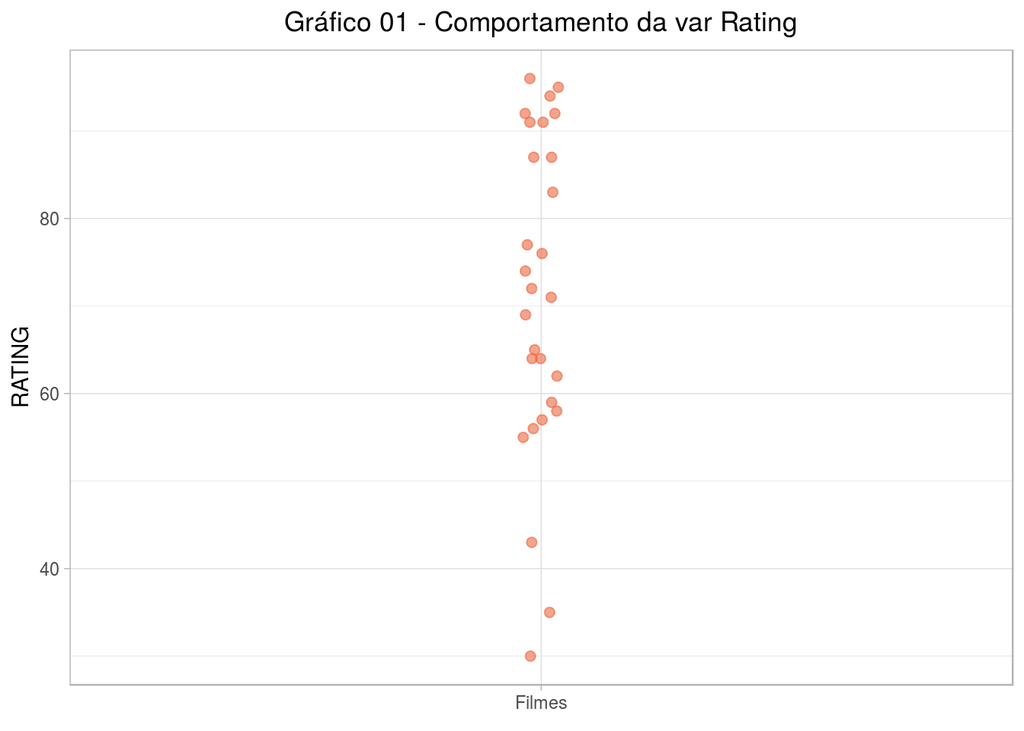

```r
filmes %>%
  ggplot(aes(x = "Filmes", y = RATING)) +
  geom_jitter(width = .02, height = 0, size = 2, alpha = .6, color="#EB6841") +
  theme(plot.title = element_text(hjust = 0.5)) +
  labs(title="Gráfico 01 - Comportamento da var Rating", x= element_blank())
```

Visualmente, há vários pequenos grupos (filmes que possuem rating próximos).

### Box Office

Repetindo o processo para a variávei Box Office (tr: Bilheteria).

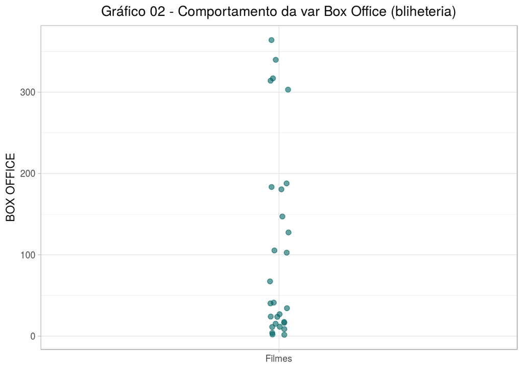

```r
filmes %>%
  ggplot(aes(x = "Filmes", y = `BOX OFFICE`)) +
  geom_jitter(width = .02, height = 0, size = 2, alpha = .6, color="#036564") +
  theme(plot.title = element_text(hjust = 0.5)) +
  labs(title="Gráfico 02 - Comportamento da var Box Office (bliheteria)", x= element_blank())
```

Aqui, os dados estão mais dispersos, com alguns grupos mais definidos.

## Agrupamento Hierárquico de duas dimensões

Agora, vamos utilizar algumas técnicas de agrupamento hierárquico de duas dimensões para identificar grupos de filmes definidos sob as características Rating e Box Office.

Primeiro, vamos entender como os dados se comportam segundo essas duas variáveis juntas!

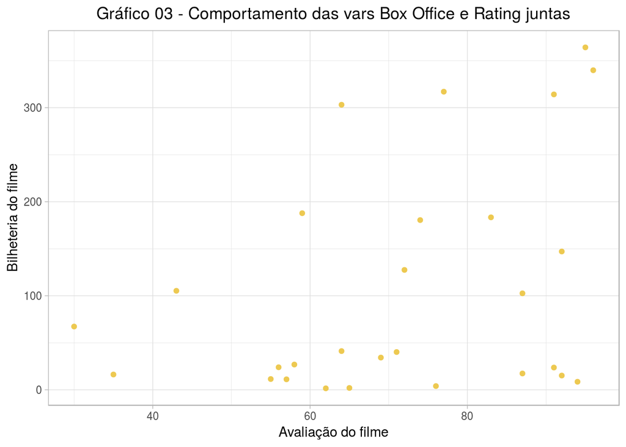

```r
filmes %>%
  ggplot(aes(x = RATING, y = `BOX OFFICE`, label = TITLE)) +
  geom_point(color="#EDC951") +
  theme(plot.title = element_text(hjust = 0.5)) +
  labs(title="Gráfico 03 - Comportamento das vars Box Office e Rating juntas",
       x="Avaliação do filme", y="Bilheteria do filme")
```

Como vemos, os dados de bilheteria variam bastante, deixando os pontos dispersos. Nesse sentido, vamos aplicar a função log aos dados de bilheteria, de modo que essa alta variação em bilheteria tenha pouca influência quando formos identificar grupos de filmes.

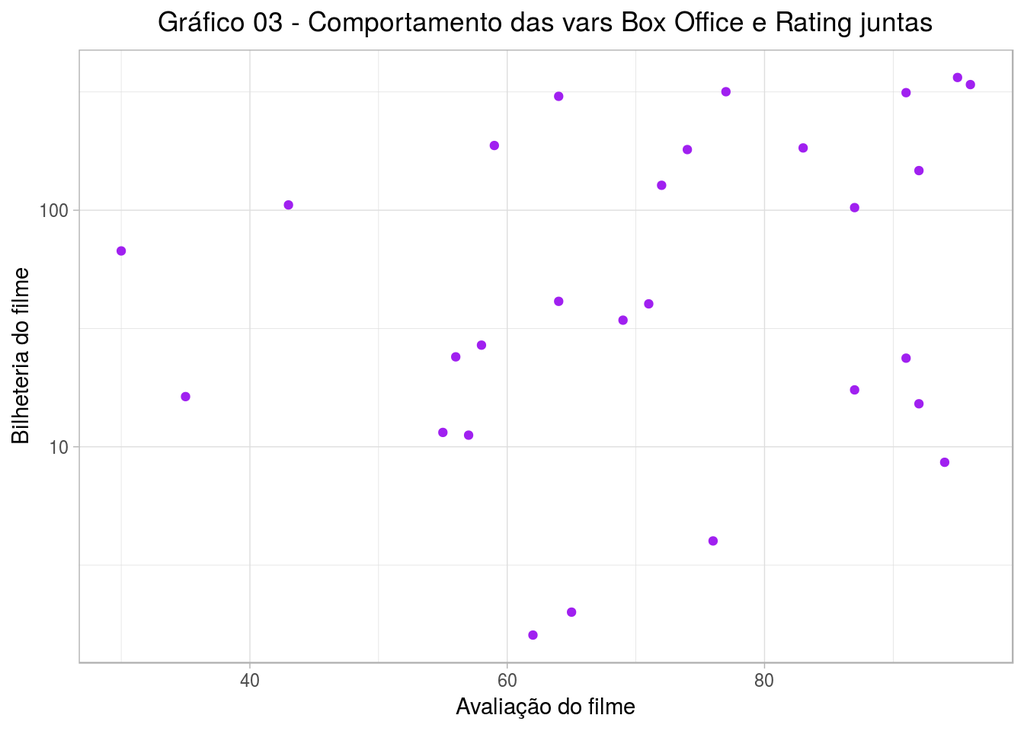

```r
filmes %>%
  ggplot(aes(x=RATING, y=`BOX OFFICE`, label = TITLE)) +
  geom_point(color="purple") +
  scale_y_log10() +
  theme(plot.title = element_text(hjust = 0.5)) +
  labs(title="Gráfico 03 - Comportamento das vars Box Office e Rating juntas",
       x="Avaliação do filme", y="Bilheteria do filme")
```

Normalizando os dados:

```r
filmes_scale = filmes %>% mutate(`BOX OFFICE` = log10(`BOX OFFICE`))
```

Calculando os grupos:

```r
agrupamento_h_2d_complete = filmes_scale %>%
    column_to_rownames("TITLE") %>%
    dist(method = "euclidean") %>%
    hclust(method = "complete")
```

Note que estamos utilizando log de Box Office. Note também que estamos utilizando o método euclidiano na função dist(). Esta função calcula distância e retorna uma matriz de distâncias. O argumento do método especifica a métrica de distância a ser usada. Outro método que poderia ser utilizado é o “manhattan”. No trecho de código acima, logo após calcular a distância, nós fazemos um aglomerativo agrupamento hierárquico (note a função hclust()). Para isso, estamos utilizando o método “complete”. Outros métodos que poderiam ser utilizados são “ward.D2”, “average”, “centroid”, “single”, dentre outros. A escolha do método define a escolha do critério de vinculação.

Vamos plotar o dendograma sobre esses dados agrupados:

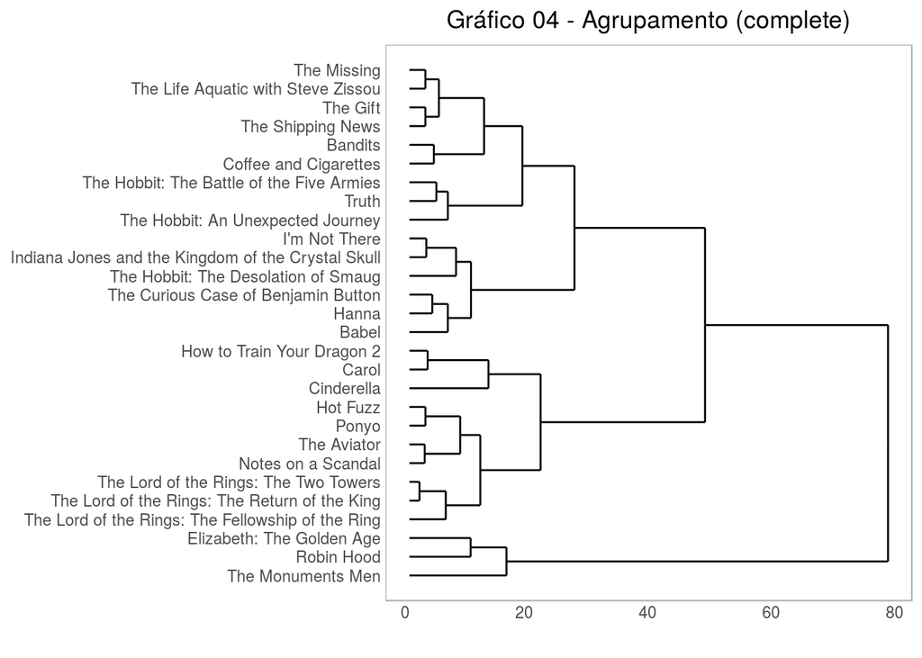

```r
ggdendrogram(agrupamento_h_2d_complete, rotate = TRUE) +
  theme(plot.title = element_text(hjust = 0.5)) +
  labs(title="Gráfico 04 - Agrupamento (complete)")
```

Para vias de comparação, vamos plotar dendogramas utilizando outros métodos de vinculação (average e single).

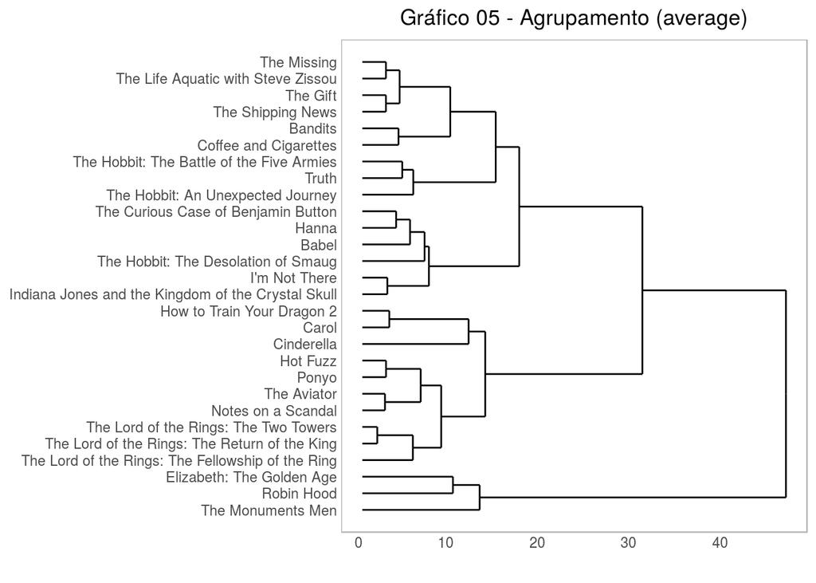

```r
agrupamento_h_2d_average = filmes_scale %>%
    column_to_rownames("TITLE") %>%
    dist(method = "euclidean") %>%
    hclust(method = "average")

ggdendrogram(agrupamento_h_2d_average, rotate = TRUE) +
    theme(plot.title = element_text(hjust = 0.5)) +
    labs(title="Gráfico 05 - Agrupamento (average)")
```

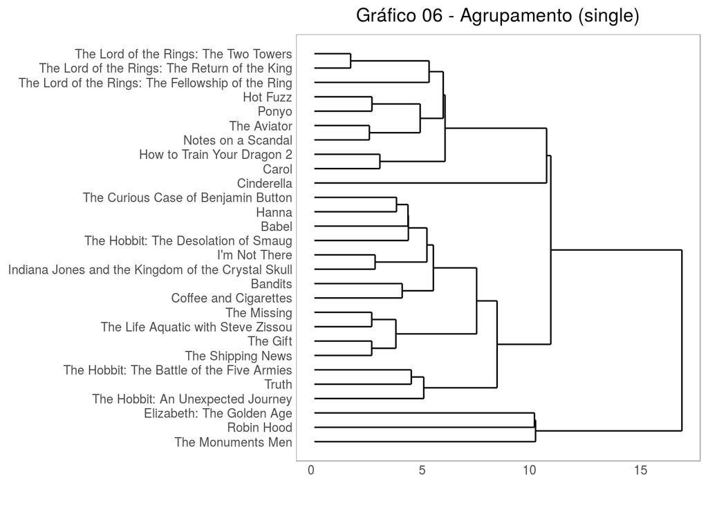

```r
agrupamento_h_2d_single = filmes_scale %>%
    column_to_rownames("TITLE") %>%
    dist(method = "euclidean") %>%
    hclust(method = "single")

ggdendrogram(agrupamento_h_2d_single, rotate = TRUE) +
    theme(plot.title = element_text(hjust = 0.5)) +
    labs(title="Gráfico 06 - Agrupamento (single)")
```

Ao longo desta análise, vamos utilizar o agrupamento pelo método average, pois nele a distância entre dois grupos é definida como a média entre cada ponto de um cluste para cada ponto do outor. No método complete, a distância entre dois grupos é definida como a maior distância entre dois pontos de grupos diferentes. E, no método single, como a menor distância.

```r
agrupamento_h_2d = agrupamento_h_2d_average
```

No gráfico abaixo, analisamos a dissimilaridade dos agrupamentos em função do número de grupos que se deseja ter. Vemos que há uma grade (a maior) diferença entre os pontos 1 e 2, como esperado, pois se todos os dados formam um só grupo, esse grupo tende a ser bem dissimilar. A diferença entre ter 2 ou 3 grupos também é bastante significativa, mas, a partir desse ponto, a dissimilaridade passa a variar menos. Nesse sentido, se quiséssemos formar a partir 4 grupos de filmes, cada grupo tenderia a ser mais homogênio entre si.

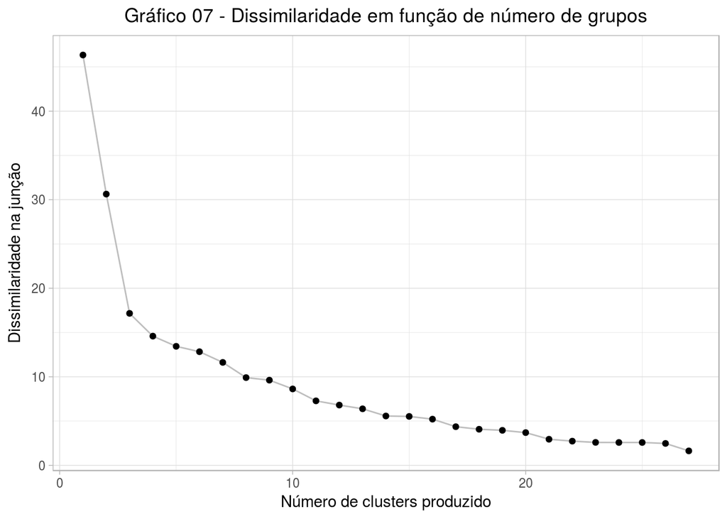

```r
data.frame(k = NROW(agrupamento_h_2d$height):1,
           height = agrupamento_h_2d$height) %>%
    ggplot(aes(x = k, y = height)) +
    geom_line(colour = "grey") +
    geom_point() +
    theme(plot.title = element_text(hjust = 0.5)) +
    labs(x = "Número de clusters produzido", y = "Dissimilaridade na junção",
         title="Gráfico 07 - Dissimilaridade em função de número de grupos")
```

Contudo, para termos mais informações, vamos trabalhar com até 6 grupos nesta análise.

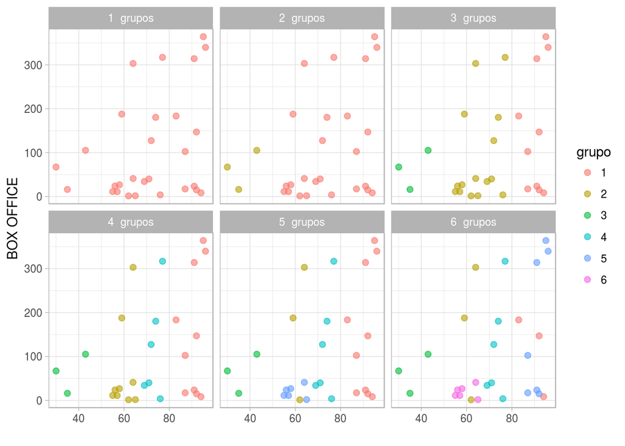

```r
plota_hclusts_2d(agrupamento_h_2d,
                 filmes_scale ,
                 c("RATING", "`BOX OFFICE`"),
                 linkage_method = "average", ks = 1:6)
```

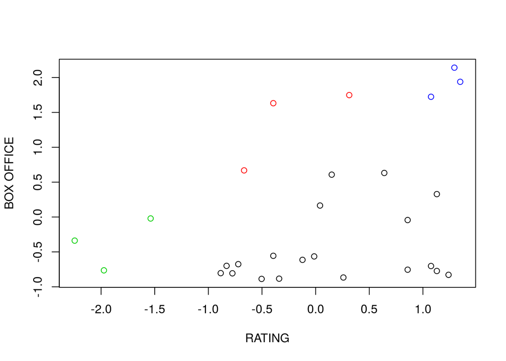

```r
agrupamento_scale = filmes
agrupamento_scale$RATING = scale(filmes$RATING)
agrupamento_scale$`BOX OFFICE` = scale(filmes$`BOX OFFICE`)

agrupamento_scale_h_2d = agrupamento_scale %>%
    column_to_rownames("TITLE") %>%
    select(RATING, `BOX OFFICE`) %>%
    dist(method = "euclidean") %>%
    hclust(method = "average")

cluster_complete <- cutree(agrupamento_scale_h_2d, k=4)

plot(agrupamento_scale %>% select(RATING, `BOX OFFICE`), col=cluster_complete)
```

E agora com seis grupos?

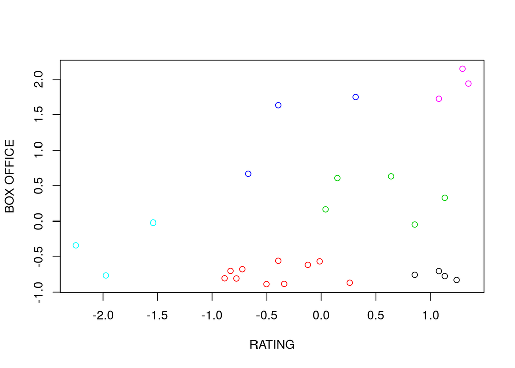

```r
plot(agrupamento_scale %>% select(RATING, `BOX OFFICE`), col=cutree(agrupamento_scale_h_2d, k=6))
```

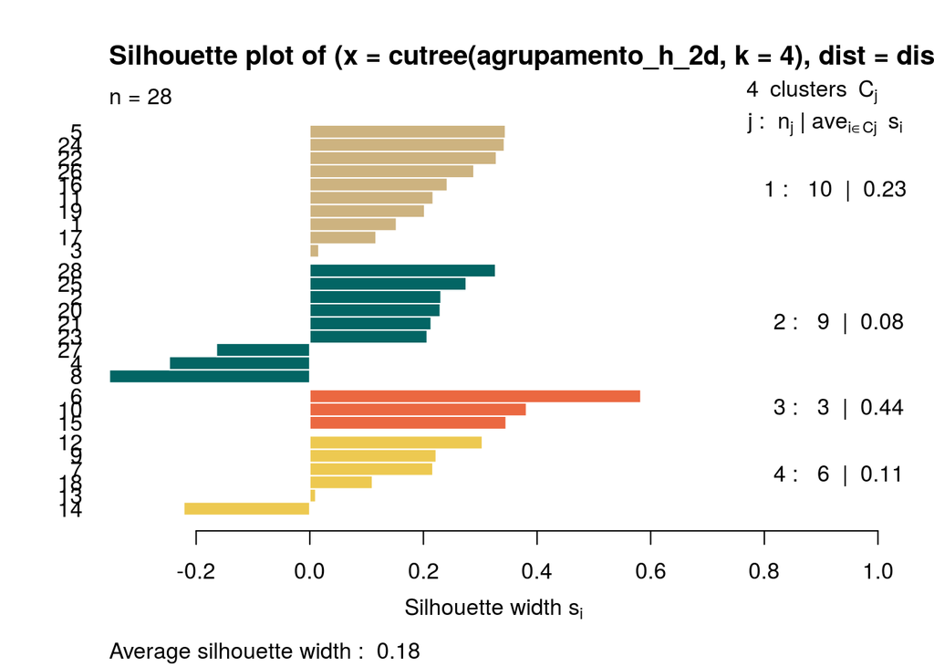

```r
distancias = filmes %>%
    column_to_rownames("TITLE") %>%
    select(RATING, `BOX OFFICE`) %>%
    mutate(`BOX OFFICE` = log10(`BOX OFFICE`)) %>%
    mutate_all(funs(scale)) %>%
    dist(method = "euclidean")

plot(silhouette(cutree(agrupamento_h_2d, k = 4), distancias), col=c("#CDB380", "#036564", "#EB6841", "#EDC951"))
```

### VISUALIZANDO..

```r
agrupamento_h_2d_dendograma = as.dendrogram(agrupamento_h_2d)
```

Customizando dendograma:

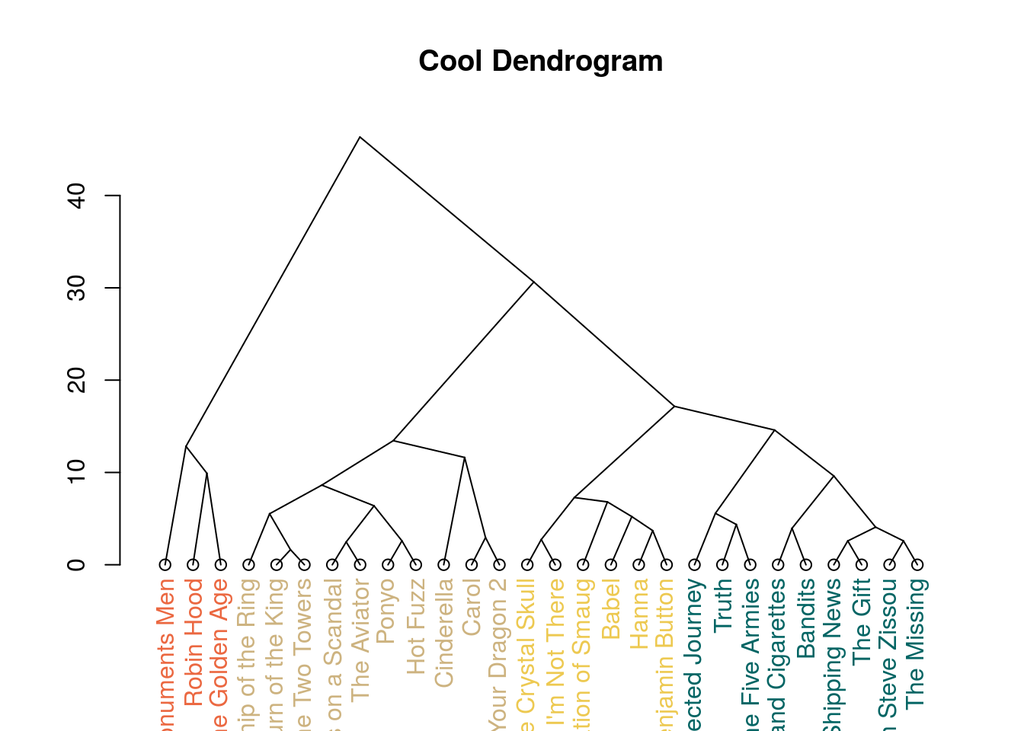

```r
labelColors = c("#CDB380", "#036564", "#EB6841", "#EDC951")

clusMember = cutree(agrupamento_h_2d, 4)

# function to get
colLab <- function(n) {
    if (is.leaf(n)) {
        a <- attributes(n)
        labCol <- labelColors[clusMember[which(names(clusMember) == a$label)]]
        attr(n, "nodePar") <- c(a$nodePar, lab.col = labCol)
    }
    n
}

clusDendro = dendrapply(agrupamento_h_2d_dendograma, colLab)

plot(clusDendro, main = "Cool Dendrogram", type = "triangle")
```

Créditos: https://rpubs.com/gaston/dendrograms Naza https://rpubs.com/mrkm_a/ClusteringWithR http://www.saedsayad.com/clustering_hierarchical.htm